# Classification of Drug Usage

Bartlomiej Karban

3/22/2020

The aim of the project is to build a predictive model for the binary classification problem. The data concerns the problem of the frequency of drug use. Each observation (human) is described by a set of demographic and psychological attributes. A possible target variable is an assignment to a class: ‘user’ or ‚non-user’ of one of the selected psychoactive substances.

The data set is shared [here](https://archive.ics.uci.edu/ml/datasets/Drug+consumption+%28quantified%29#)

The project uses the “CRISP-DM” methodology. The final result was achieved in the following steps:

1. Understanding the problem.
2. Exploratory Data Analysis and selection of the target variable.
3. Modeling.
4. Performance Assessment.
5. Recommendation.

## 1. Understanding the problem.

The provided data contains both demographic (e.g., age, gender) and psychological characteristics. Observing raw data, one can see that some of the characteristics recorded as numerical are, in fact, not - they are most likely factors whose levels have been normalized.

The problem concerns features from V2 to V6. Features V7 to V13 are the result of psychological measurement and are encoded correctly.

The other features (V14 to V32 )indicate drugs; each of them is described by categories indicating the time since last use. To reduce the task to binary classification, they coded into two new ones: “user,” “non-user.”

The structure of the described data is presented below.

```
## Observations: 1,885
## Variables: 32
## $ V1  <int> 1, 2, 3, 4, 5, 6, 7, 8, 9, 10, 11, 12, 13, 14, 15, 16, 17, 18, 19…
## $ V2  <dbl> 0.49788, -0.07854, 0.49788, -0.95197, 0.49788, 2.59171, 1.09449, …
## $ V3  <dbl> 0.48246, -0.48246, -0.48246, 0.48246, 0.48246, 0.48246, -0.48246,…
## $ V4  <dbl> -0.05921, 1.98437, -0.05921, 1.16365, 1.98437, -1.22751, 1.16365,…
## $ V5  <dbl> 0.96082, 0.96082, 0.96082, 0.96082, 0.96082, 0.24923, -0.57009, 0…
## $ V6  <dbl> 0.12600, -0.31685, -0.31685, -0.31685, -0.31685, -0.31685, -0.316…
## $ V7  <dbl> 0.31287, -0.67825, -0.46725, -0.14882, 0.73545, -0.67825, -0.4672…
## $ V8  <dbl> -0.57545, 1.93886, 0.80523, -0.80615, -1.63340, -0.30033, -1.0920…
## $ V9  <dbl> -0.58331, 1.43533, -0.84732, -0.01928, -0.45174, -1.55521, -0.451…
## $ V10 <dbl> -0.91699, 0.76096, -1.62090, 0.59042, -0.30172, 2.03972, -0.30172…
## $ V11 <dbl> -0.00665, -0.14277, -1.01450, 0.58489, 1.30612, 1.63088, 0.93949,…
## $ V12 <dbl> -0.21712, -0.71126, -1.37983, -1.37983, -0.21712, -1.37983, -0.21…
## $ V13 <dbl> -1.18084, -0.21575, 0.40148, -1.18084, -0.21575, -1.54858, 0.0798…
```

[output cut: 19 more lines]

After re-coding and renaming of the features, the data frame looks as follows:

```
## Observations: 1,885
## Variables: 31
## $ Neuroticism          <dbl> 0.31287, -0.67825, -0.46725, -0.14882, 0.73545, …
## $ Extraversion         <dbl> -0.57545, 1.93886, 0.80523, -0.80615, -1.63340, …
## $ OpennessToExperience <dbl> -0.58331, 1.43533, -0.84732, -0.01928, -0.45174,…
## $ Agreeableness        <dbl> -0.91699, 0.76096, -1.62090, 0.59042, -0.30172, …
## $ Conscientiousness    <dbl> -0.00665, -0.14277, -1.01450, 0.58489, 1.30612, …
## $ Impulsiveness        <dbl> -0.21712, -0.71126, -1.37983, -1.37983, -0.21712…
## $ SensationSeeing      <dbl> -1.18084, -0.21575, 0.40148, -1.18084, -0.21575,…
## $ Alcohol              <fct> user, user, user, user, user, user, user, user, …
## $ Amphet               <fct> user, user, non_user, non_user, non_user, non_us…
## $ Amyl                 <fct> non_user, user, non_user, non_user, non_user, no…
## $ Benzos               <fct> user, non_user, non_user, user, non_user, non_us…
## $ Caffeine             <fct> user, user, user, user, user, user, user, user, …
## $ Cannabis             <fct> non_user, user, user, user, user, non_user, non_…
```

[output cut: 18 more lines]

The next step is Exploratory Data Analysis and selecting a Target variable for modeling.

## 2. Exploratory Data Analysis. Selecting target variable.

First, the distribution of success (“user”) in all variables that can be the target variable in the classification model was checked. As you can see, the variables have a different degree of success balance. **Based on this analysis, “Benzos” was chosen as the target variable - one of the reasons is a good balance of this variable. Another reason is that benzodiazepines are not an illegal drug, but a prescription medicine and this fact may be of interest to a pharmaceutical company.**

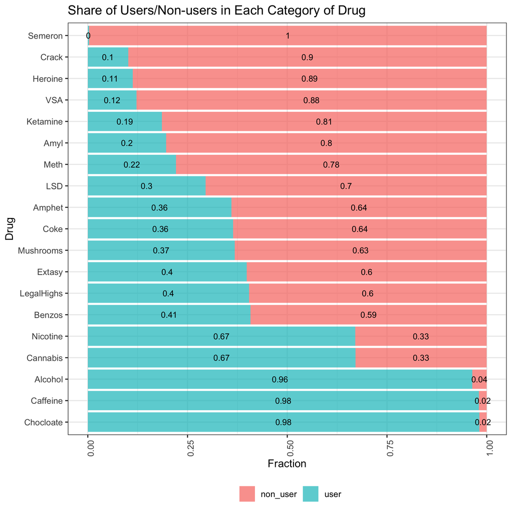

In the next step, the distribution of categorical variables was checked to find rare categories. All categories with less than 3% were merged into one ‘other’ category.

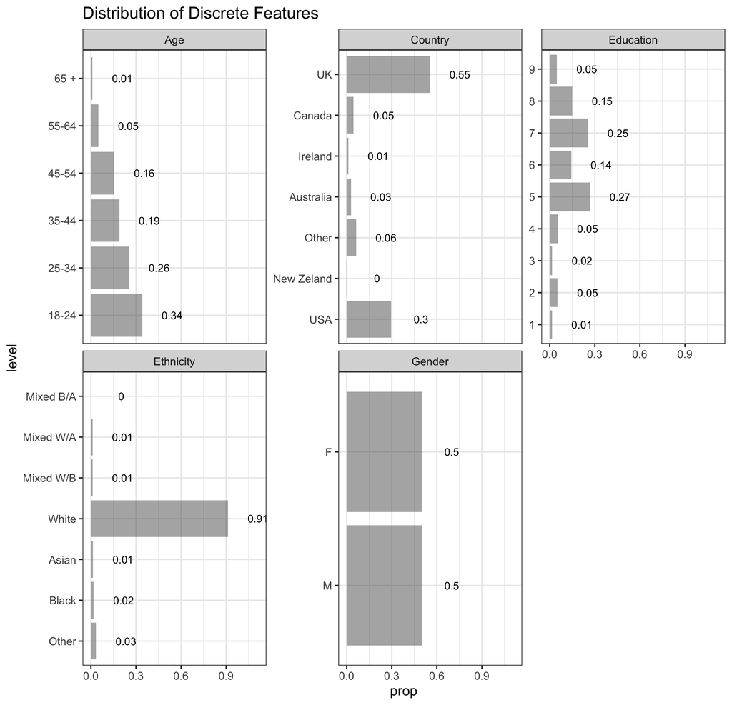

Once the rare categories were merged, the distribution of success in each of the category variables was checked. As shown in the figure below, there is a noticeable relationship between the target variable and age, gender or education.

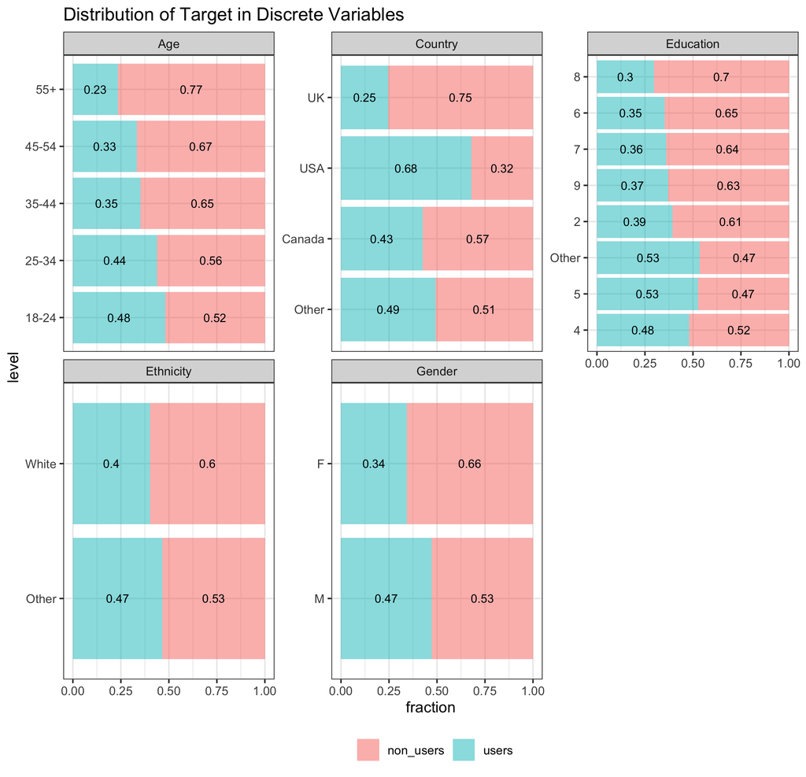

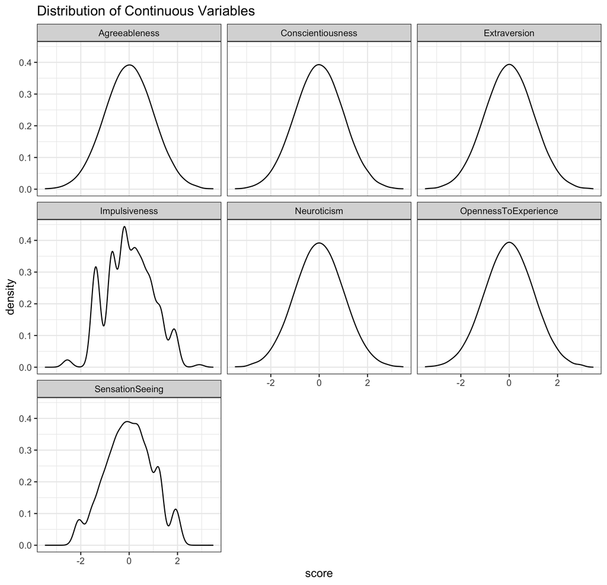

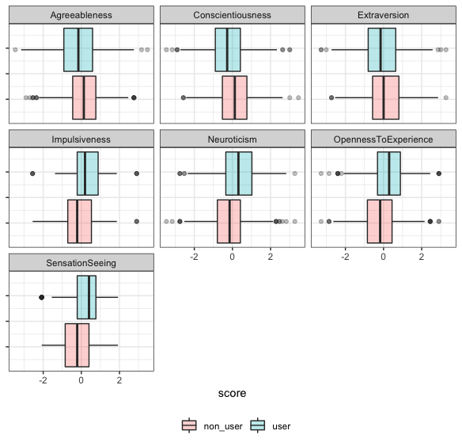

The last stage of exploratory analysis is to check the correlation. In the correlation matrix, there are no variables that are strongly correlated with each other. Additionally, the logistic regression model is checked for collinearity using the Variance Inflation Factor. If any of the variables enter collinearity, it’s removed.

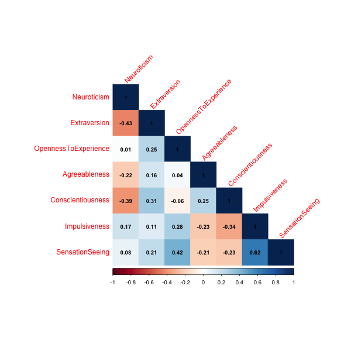

**The existence of NA’s was also checked. The data is complete.**

```r
anyNA(preprocessed_data)
```

```
## [1] FALSE
```

## 3. Modeling

In this phase 3 classification models are proposed:

- Logistic Regression model,
- Decision Tree,
- Random Forest.

The data was divided into two parts: training-validation (70%) and testing (30%). With the use of the training-validation set, models were built (including the search for the best hyperparameters - using repetitive cross-validation), and performance was checked on the test one. Of course, the performance was compared between the training-validation set and the test set in order to check if the models are overfitted.

For Logistic Regression and Decision Tree, the model form was presented. The quality of each model was shown using a confusion matrix calculated on the test set. Comparison of the models with each other, and the results for the training-validation sets are presented further.

### Logistic Regression.

```
##
## Call:
## glm(formula = Benzos ~ Neuroticism + OpennessToExperience + SensationSeeing +
##     Age.25.34 + Age.35.44 + Age.45.54 + Gender.M + Country.USA,
##     family = "binomial", data = glm_data, subset = ix_trn)
##
## Deviance Residuals:
##     Min       1Q   Median       3Q      Max
## -2.2136  -0.8639  -0.5849   0.9878   2.3144
##
## Coefficients:
##                      Estimate Std. Error z value Pr(>|z|)
## (Intercept)          -1.29213    0.14349  -9.005  < 2e-16 ***
## Neuroticism           0.47056    0.06552   7.182 6.85e-13 ***
## OpennessToExperience  0.23627    0.07292   3.240  0.00119 **
## SensationSeeing       0.33382    0.07680   4.346 1.38e-05 ***
## Age.25.34             0.38263    0.16498   2.319  0.02038 *
## Age.35.44             0.52261    0.18416   2.838  0.00454 **
## Age.45.54             0.41084    0.20184   2.036  0.04180 *
## Gender.M              0.41828    0.13057   3.203  0.00136 **
## Country.USA           1.38023    0.15063   9.163  < 2e-16 ***
## ---
## Signif. codes:  0 '***' 0.001 '**' 0.01 '*' 0.05 '.' 0.1 ' ' 1
##
## (Dispersion parameter for binomial family taken to be 1)
##
##     Null deviance: 1786.3  on 1320  degrees of freedom
## Residual deviance: 1499.2  on 1312  degrees of freedom
## AIC: 1517.2
##
## Number of Fisher Scoring iterations: 4
```

```
## Confusion Matrix and Statistics
##
##           Reference
## Prediction non_user user
##   non_user      271  103
##   user           63  127
##
##                Accuracy : 0.7057
##                  95% CI : (0.6662, 0.743)
##     No Information Rate : 0.5922
##     P-Value [Acc > NIR] : 1.47e-08
##
##                   Kappa : 0.3737
##
##  Mcnemar's Test P-Value : 0.00247
##
##             Sensitivity : 0.5522
##             Specificity : 0.8114
##          Pos Pred Value : 0.6684
##          Neg Pred Value : 0.7246
##              Prevalence : 0.4078
##          Detection Rate : 0.2252
##    Detection Prevalence : 0.3369
##       Balanced Accuracy : 0.6818
##
##        'Positive' Class : user
##
```

### Decision Tree.

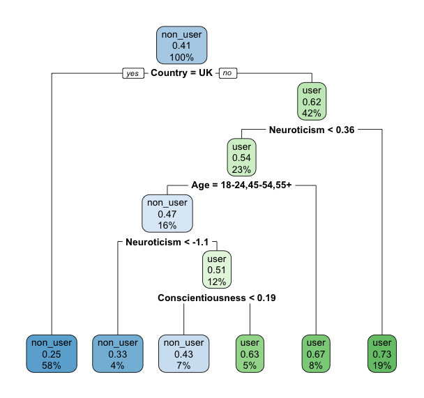

```
## Confusion Matrix and Statistics
##
##           Reference
## Prediction non_user user
##   non_user      254  105
##   user           80  125
##
##                Accuracy : 0.672
##                  95% CI : (0.6315, 0.7106)
##     No Information Rate : 0.5922
##     P-Value [Acc > NIR] : 5.72e-05
##
##                   Kappa : 0.3092
##
##  Mcnemar's Test P-Value : 0.07765
##
##             Sensitivity : 0.5435
##             Specificity : 0.7605
##          Pos Pred Value : 0.6098
##          Neg Pred Value : 0.7075
##              Prevalence : 0.4078
##          Detection Rate : 0.2216
##    Detection Prevalence : 0.3635
##       Balanced Accuracy : 0.6520
##
##        'Positive' Class : user
##
```

### Random Forest.

```
## Confusion Matrix and Statistics
##
##           Reference
## Prediction non_user user
##   non_user      254   94
##   user           80  136
##
##                Accuracy : 0.6915
##                  95% CI : (0.6516, 0.7294)
##     No Information Rate : 0.5922
##     P-Value [Acc > NIR] : 6.79e-07
##
##                   Kappa : 0.3551
##
##  Mcnemar's Test P-Value : 0.3244
##
##             Sensitivity : 0.5913
##             Specificity : 0.7605
##          Pos Pred Value : 0.6296
##          Neg Pred Value : 0.7299
##              Prevalence : 0.4078
##          Detection Rate : 0.2411
##    Detection Prevalence : 0.3830
##       Balanced Accuracy : 0.6759
##
##        'Positive' Class : user
##
```

## 4. Performance Assesment.

As indicated earlier, the models were compared with each other. The conclusions are as follows:

- The decision tree model achieved the worst results.
- The random forest model on the test data has a slightly better score in the AUC criterion than the logistic regression model, but worse in the precision criterion. Moreover, it seems to overfit. Its interpretability is limited (this can be done with libraries such as DALEX or LIME).
- The logistic regression model has the best result in the precision criterion. It is easily interpreted.

The results are summarized in the table below.

| model | auc_train | auc_test | auc_test_sd | precision_test | recall_test |
| --- | --- | --- | --- | --- | --- |
| glm | 0.763 | 0.743 | 0.022 | 0.668 | 0.552 |
| decision tree | 0.716 | 0.701 | 0.021 | 0.610 | 0.543 |
| random forest | 0.816 | 0.745 | 0.020 | 0.630 | 0.591 |

The figure below shows the ROC curves calculated on the test set for each model.

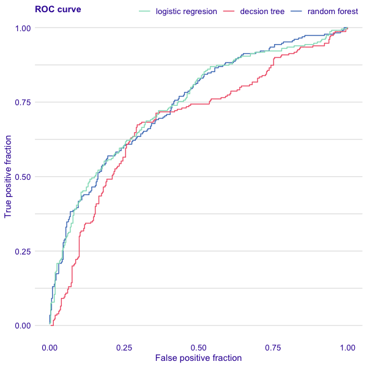

## 5. Recommendation.

For implementation, I recommend the logistic regression model. It has relatively good results and is easy to interpret.

**The model formula and classification quality should be discussed with field experts.** It should be emphasized that by changing the cut-off for the probability of classification to one of two classes, we can have an impact on the results of the measurements from the confusion matrix.